# Data Investigation using tmdb dataset

An explanatory data analysis was performed using 'The Movie Database' (tmbd). tmbd is an editable database for both movies and TV shows. The tmdb dataset used for this experiment is in a csv file format with multiple columns providing wide variety of information on movies and/or tv shows with records going back to the 1960's.

The code below imports the modules required for this analysis. 'read_csv' reads the dataset and loads it as a pandas dataframe.

All variables present in the dataset is displayed below. Presence of missing data is indicated by True/False. 'True' indicate missing values in the variable. In that case, missing values are removed first before conducting any analysis.

```python
#Import modules required for this analysis
import numpy as np
import pandas as pd
import pandas.tseries
import datetime as dt
import calendar
import matplotlib.pyplot as plt
from matplotlib.ticker import AutoMinorLocator
from statsmodels.stats.outliers_influence import variance_inflation_factor
np.warnings.filterwarnings("ignore")
import statsmodels.api as sm
np.warnings.resetwarnings()

#Read tmdb csv data
tmdb_data = pd.read_csv('tmdb-movies.csv')

#Variables available in the dataset
#Detected missing values shown as 'True' or otherwise display 'False' for no
#missing data
tmdb_data.isnull().any()
```

```
id                      False
imdb_id                  True
popularity              False
budget                  False
revenue                 False
original_title          False
cast                     True
homepage                 True
director                 True
tagline                  True
keywords                 True
overview                 True
runtime                 False
genres                   True
production_companies     True
release_date            False
vote_count              False
vote_average            False
release_year            False
budget_adj              False
revenue_adj             False
dtype: bool
```

The basis of this study is to present some study questions and explore the dataset related to those study questions. The results are displayed using several visulaization techniches.

Study Question 1: Using genres as a criteria, explore the trends across months. Is there any discernible trend observed for each month?

Study Question 2: Using the production company of your choice, discuss the trends in the company growth. Is the trend increasing or decreasing?

## Analysis for Study Question 1

Genres is a very important characteristic in movies. Genres help classify movies into a specific category. In most cases however, movies are generally a blend of multiple genres. For example a romantic movie can also be comedy. Such movies usually comes under Romantic/Comedy genre.

For this experiment, to keep the analysis simple and straightforward, five broad sectors of genre were used to classify movies and are listed below.

GENRE LIST: 1:Fiction 2:Thriller 3:Romance 4:Comedy 5:Horror

Movies that are a blend of mutpliple genres are shrunk to a single genre category by matching based on the rank order of genre list. This means that if a movie is classified as Thriller/Fiction/Drama, then this movie falls under the 'Fiction' category. If a movie is classified as Horror/Comedy, then this movie falls under 'Comedy' category.

Only a subset of movie data that contain one or more of these five broad genre types are used in this analysis. Movies that do not include any of the genres listed above are ignored.

The genre list is stored as a python list. A list is an ordered collection of items and each item/element in the list has an index value (0,1,2,3,...,n). The index vales specifies the order of the items in the list.

```python
#Get month from release date variable
tmdb_data['release_month'] = pd.DatetimeIndex(tmdb_data['release_date']).month

#Get full month names instead of integer month values
tmdb_data['release_month'] = tmdb_data['release_month'].apply(lambda x: calendar.month_name[x])

#Select only release month and genres variables and save it
#to new pandas dataframe called genre_data.
#Drop missing values from the dataset
genre_data = tmdb_data[['release_month','genres']].dropna().reset_index(drop=True)

#Define genre list.
genre_list = ['Fiction','Thriller','Romance','Comedy','Horror']

#Check each value in genres column in the genre_data dataset and extract the genre contained
#in dataset that matches first with genre_list.
#Replace the genre column with the genre identified from the genre list
for genre in genre_list:
    genre_data.loc[genre_data['genres'].str.contains(genre),'genres']=genre
```

Bar plots were used to assess the monthly distribution of genres averaged across years. Bar plots are an effiecient way to display categorical data by group. The amounts within each group is presented using the length of the bars and the amount value can be read by the scale on the y-axis for vertical bars or in case of horizontal bars, the scale can be read from the x-axis. It is important to note that this analysis use movies from not just hollywood but also international like bollywood.

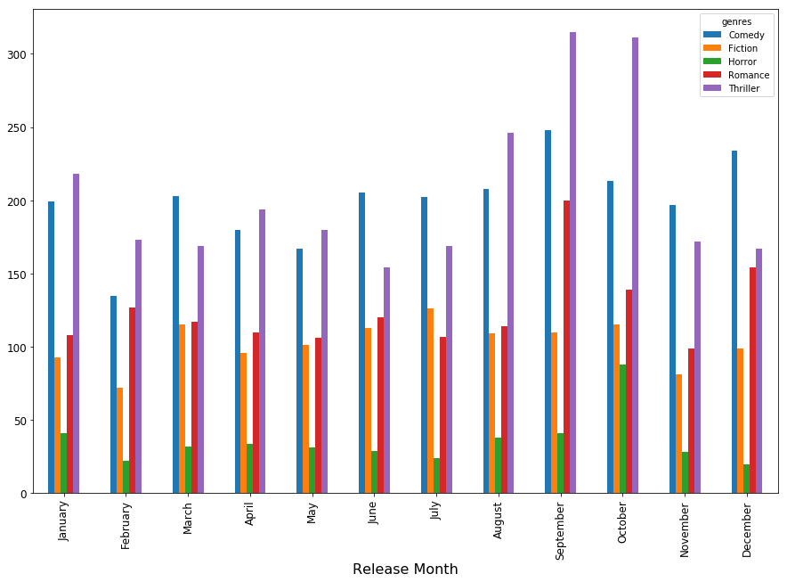

```python
#For each month, count the number of genre release under each category
genre_data = genre_data[genre_data['genres'].isin(genre_list)].groupby('release_month')['genres'].value_counts().reset_index(name='count')

#Create a pivot table with index as month names, column values with genre types and
#count is the frequency value for the total number of movies realeased in that month for
#particular genre
plot_file = genre_data.pivot(index='release_month', columns='genres', values= 'count')
#plot_file
#Reorder the months column so that a column follows a chronological order
months= ['January', 'February', 'March','April','May','June','July', 'August', 'September', 'October', 'November', 'December']
plot_file = plot_file.reindex(months)

ax = plot_file.plot(kind='bar', figsize=(15,10), fontsize=12)
ax.set_xlabel('Release Month', fontsize=16)
plt.show()
```

The bar plots indicate Thriller and Comedy genres are favorites for all months. Thriller movies are however released more in the months of September and October. Another interesting fact and also quite obvious is that Horror movies are popular during the month of October, just in time for Halloween!

Fiction genre remains consistent through out all months. Romance genre are most popular in the month of September. In North America September month is the on set for fall season.

On that note, Fall season is ideal for slipping into the most comfy clothes and enjoying the not too hot not too cold weather and romantic movies can be definitely fun to watch during this time of the year!

Over all the bar plots display a certain amount of seasonal dependency.

## Analysis to explore Study Question 2

Data analysis was conducted on Warner Bros production company to identify the company's growth trends. Warner Bros is one of the largest entertainment group in Hollywood and has produced some of the best movies in history. Movies like Casablanca, Inception, Harry Potter and not to forget horror movies like The Exorcist that probably kept people awake and scared at night for months all come under this production banner. Founded in 1923, Warner Bros to date has been a forerunner with some of the best reviewed movies.

A line plot was created to see the trend component for Warner Bros production using number of movies releaser per year and how this translates to the total revenue made each year.

The code below generates a line plot with primary y axis indicating Total Revenue (in US Dollars) and number of movies per year on the secondary Y axis (on the right). X axis shows the years in chronological order.

```python
#Create a pandas dataframe using the master dataframe 'tmdb' and store all variables of interest in the dataset.
#Remove all missing vales from the dataset. For any missing value present, entire row is removed.

warner_bros = tmdb_data[['release_year', 'production_companies','popularity', 'revenue','vote_count']].dropna()

#Choose Production company of interest
production_company=['Warner Bros']

#For loop to go through each value in the production company column and extract those that contain 'Warner Bros'
for company in production_company:
    warner_bros.loc[warner_bros['production_companies'].str.contains(company),'production_companies']=company

warner_bros = warner_bros[warner_bros['production_companies'].isin(production_company)].reset_index(drop=True)

#Check first 5 rows of the dataset
warner_bros.head()
```

|  | release_year | production_companies | popularity | revenue | vote_count |
| --- | --- | --- | --- | --- | --- |
| 0 | 2015 | Warner Bros | 6.189369 | 183987723 | 1937 |
| 1 | 2015 | Warner Bros | 4.907832 | 470490832 | 2060 |
| 2 | 2015 | Warner Bros | 3.053421 | 108145109 | 1548 |
| 3 | 2015 | Warner Bros | 2.814802 | 194564672 | 1255 |
| 4 | 2015 | Warner Bros | 2.345821 | 93820758 | 805 |

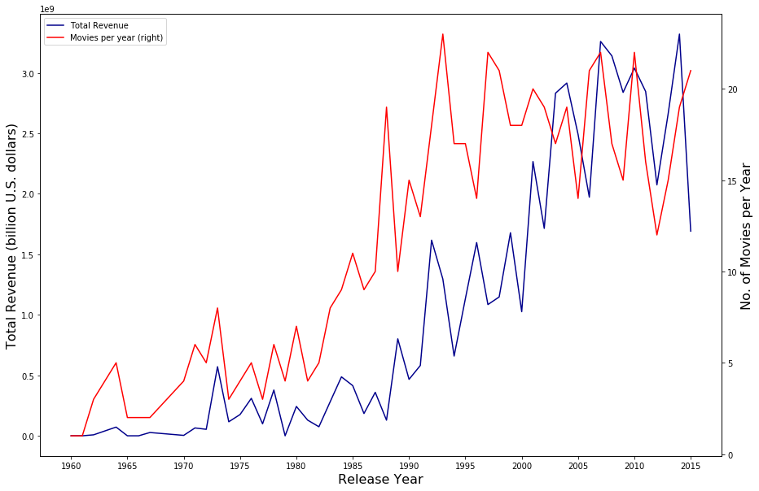

```python
#Group by year, total all revenue within each year and count numbers of rows within each group
#Save in new pandas dataframe 'df'
df = warner_bros.groupby('release_year')['revenue'].agg(['sum','count']).reset_index()


#To stach two plots on top of each other
#Create a duplicate plot that share same x axis
ax2=ax.twinx()

#Plot 1: Total revenue as a function of year
ax=df.plot(kind='line', x='release_year', y = 'sum', color='DarkBlue', label='Total Revenue')
#Customize plots-x and y axis labels, x axis breaks
ax.set_xlabel('Release Year',fontsize=16)
ax.set_ylabel('Total Revenue (billion U.S. dollars)',fontsize=16)
ax.xaxis.set_ticks(np.arange(1960, 2020, 5))
#Plot2: Number of movies released per year as a function of year plotted on the secondary y axis
ax2=df.plot(kind='line', x='release_year', y = 'count', secondary_y=True, figsize=(15,10),color='Red', label='Movies per year', ax=ax)
#set axis labels
ax.set_xlabel('Release Year',fontsize=16)
ax2.set_ylabel('No. of Movies per Year', fontsize=16)

plt.show()
```

Years 1960-1970 indicate an average of two movies released per year. Year 1973 released 8 movies after which there was downfall until the 1980's. In the year 1972, Warner Bros along with Columbia as part of their cost cutting strategies formed a third company called The Burbank Studios (TBS). TBS primary reposnisbilty was ground keeping of studios but due to the reluctance of either companies to spend on capital upgrades led to fewer realeases during that year. During the same period (late 1970's), Warner retired from the production company and also died due to health complications.

It is interesting to note that years 2014 and 2015 had 19 and 21 movie releases repsectively but the revenue made in 2015 saw a drop of nearly 50%.

Additional tests were conducted using the warner bros dataset.

The test aimed to create a linear regression model for revenue (dependent variable) as a function of popularity and vote counts (independent variables).

Multiple Linear Regression is used when two or more predictors (independent variables) are used to asses the the outcome variable (dependent variable).  
In order to develop a mulpiple linear regression model, scatter plots were created to first check for linear correlation between the dependent variable (revenue) and the independent variables (popularity and vote count).

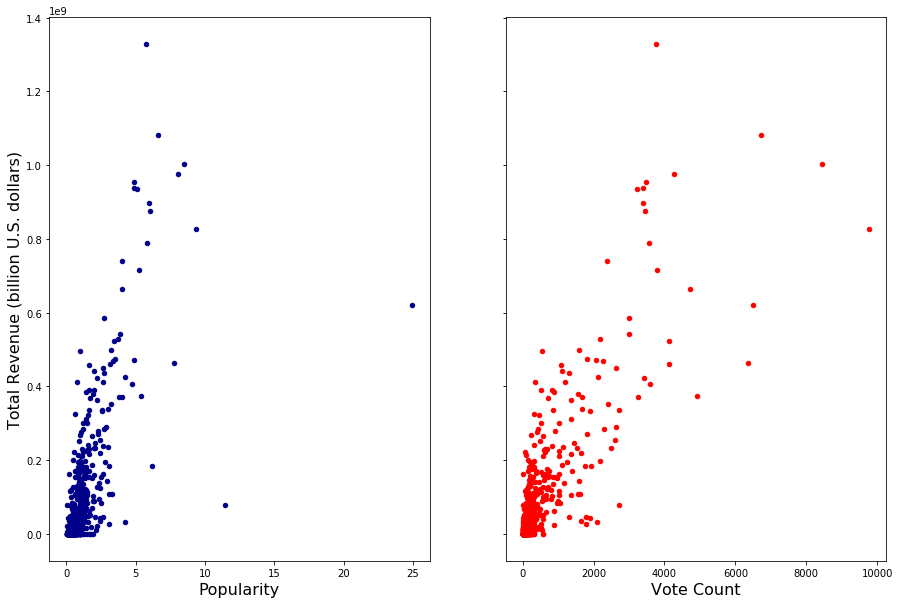

```python
#Scatter plots showing revenue as a function of popularity and revenue as a function of vote count

#Create two plots side-by-side with the same y-axis
fig, (ax, ax2) = plt.subplots(ncols=2, sharey=True)
ax=warner_bros.plot(kind='scatter', x='popularity', y = 'revenue', color='DarkBlue', ax=ax)
ax2=warner_bros.plot(kind='scatter', x='vote_count', y = 'revenue', color='Red', ax=ax2, figsize=(15,10))
#Set axis labels
ax.set_ylabel('Total Revenue (billion U.S. dollars)',fontsize=16)
ax.set_xlabel('Popularity',fontsize=16)
ax2.set_xlabel('Vote Count', fontsize=16)
plt.show()
```

For simple or multiple regression analysis, linear relationshiop between the dependent and independent variables is important. From the two scatter plots, revenue seems to be linearly associated with both vote counts and popularity. For a multiple linear regression model, another important criteria is that the predictor variables should be independent of each other. In case of strong correlation between the predictors, the predictor that has the least influence on the outcome variables is dropped from the analysis. Variation Inflation factors (VIF) was used to test the presence of mulicollinearity.

```python
#code for VIF analysis

#Select variables needed for regression analysis and save in a new pandas dataframe
warner_bros_regress = warner_bros[['popularity', 'revenue','vote_count']].reset_index(drop=True)
#adding constant ensures that y axis is not forced to pass through the origin
X = sm.add_constant(warner_bros_regress)
pd.Series([variance_inflation_factor(X.values, i)
               for i in range(X.shape[1])],
              index=X.columns)
```

```
const         1.520412
popularity    3.252228
revenue       3.067651
vote_count    5.140135
dtype: float64
```

VIF analysis indicate fairly large VIF for vote count variable. This suggests that vote count is highly correlated with one or more variables.

A pearson test was used to calculate the correlation coefficent between vote count and popularity to check if the predictors influence each other. Correlation coefficients were also calculated for revenue-vote count and revenue-popularity. The results suggest a strong correlation between popularity and vote count (0.83).

Pearson test also indicated that vote count is a better predictor (0.82). Popularity was therefore removed from the analysis and a simple linear regression test was used to check the effect on revenue from vote count.

```python
#column based pearson correlation
warner_bros_regress.corr()
```

|  | popularity | revenue | vote_count |
| --- | --- | --- | --- |
| popularity | 1.000000 | 0.695645 | 0.831867 |
| revenue | 0.695645 | 1.000000 | 0.820653 |
| vote_count | 0.831867 | 0.820653 | 1.000000 |

The following methods were used to fit a simple linear regression model using vote count as predictor variable and the revenue as the outcome.

```python
#independent variable/predictor
x = warner_bros['vote_count']

#dependent variable/outcome
y = warner_bros['revenue']

#add constant so y axis is not forced to pass through origin
x=sm.add_constant(x)

lm_model = sm.OLS(y,x).fit()

lm_model.summary()
```

OLS Regression Results

| Dep. Variable: | revenue | R-squared: | 0.673 |
| --- | --- | --- | --- |
| Model: | OLS | Adj. R-squared: | 0.673 |
| Method: | Least Squares | F-statistic: | 1277. |
| Date: | Tue, 17 Apr 2018 | Prob (F-statistic): | 1.41e-152 |
| Time: | 15:10:51 | Log-Likelihood: | -12299. |
| No. Observations: | 621 | AIC: | 2.460e+04 |
| Df Residuals: | 619 | BIC: | 2.461e+04 |
| Df Model: | 1 |  |  |
| Covariance Type: | nonrobust |  |  |

|  | coef | std err | t | P>\|t\| | [0.025 | 0.975] |
| --- | --- | --- | --- | --- | --- | --- |
| const | 2.618e+07 | 4.28e+06 | 6.109 | 0.000 | 1.78e+07 | 3.46e+07 |
| vote_count | 1.389e+05 | 3888.172 | 35.731 | 0.000 | 1.31e+05 | 1.47e+05 |

| Omnibus: | 288.330 | Durbin-Watson: | 1.914 |
| --- | --- | --- | --- |
| Prob(Omnibus): | 0.000 | Jarque-Bera (JB): | 4802.324 |
| Skew: | 1.626 | Prob(JB): | 0.00 |
| Kurtosis: | 16.230 | Cond. No. | 1.22e+03 |

'Orinary Least Squares' (OLS) method was used to fit the regression model. OLS method minimizes the errors (or the residuals) in the data. The coefficient 1.389e+5 indicates the estimated increase in revenue for every additional vote count. The r-squared from the fitted model indicates about 70% model variability. This means that vote count has about 70% affect on the revenue.t-score and p-values are used for hypothesis testing. Critical t-value for a two tail test with 95% confidence interval with 619 degrees of freedom is around 1.964. t-score from the regression test is higher than the critical value, which means that the test is significant.

Reference for t-table:https://home.ubalt.edu/ntsbarsh/Business-stat/StatistialTables.pdf

## Limitations:

The bar plots indicating distribution of genres across months uses movie data from not just Hollywood but also other international movies. The analysis does not specify the breakdown between the Hollywood movies and international movies. Also the bar plots indicate the trends across months for only five broad genre types.

The line plots and regression model is representative of only one production company. It is also important to note that in certain cases multiple production companies jointly participate in producing a movie. This analysis for simplicity purposes extracts any data that comes under Warner Bros banner.

When building regression models, general practise is to not use the entire dataset, instead the complete dataset is broken down into K subsets. Regression model is fit on the training dataset (k-1) and the predictions from the model is applied to the test (last subset) dataset to assess the accuracy of the model. This method is referred to as the K-Fold Cross Validation technique. In this analysis however, since a single production company data was used as a case study to assess the relationship between two variables, building the model for machine learning didn't seem necessary.

## References

https://stackoverflow.com

https://medium.freecodecamp.org/data-science-with-python-8-ways-to-do-linear-regression-and-measure-their-speed-b5577d75f8b